# Egzaminas

Judilė Bernackaitė, 1811312

2019-06-20 12:23

# 1 Prieš pradedant

- Ant desktopo sukurkite direktoriją “exam”, į ją išsaugokite šį dokumentą pakeisdami jo pavadinimą į “StudNr_Vardas_Pavarde.Rmd” (nenaudokite lt rašmenų) bei atitinkamai pakeisdami viršuje esančius laukelius: “author: …”
- Sumegzkite iškart šį dokumentą į .html failą ir įsitikinkite, jog viskas veikia gerai, tik tada pradėkite spręsti uždavinius.

# 2 Pasiruošimas

Šioje kodo dalyje surašykite visus paskesnėse dalyse naudojamus R paketus. Kodas turi patikrinti, ar paketas yra instaliuotas, jeigu ne, instaliuoti bei užloadinti. Jeigu darbo eigoje prireikia naujų paketų, nepamirkite čia juos įrašyti.

```r
if(!require(eurostat)) install.packages("eurostat"); require(eurostat)
if(!require(tidyverse)) install.packages("tidyverse"); require(tidyverse)
```

# 3 Istorija

Šiuo metu Jūs darbuojatės NVO “Stop skurdas”. Koks tai “influenceris” patrolino visuomenę (galimai apmokėtas privačių pensijų fondų), jog Sodroje kaupti pensijai neapsimoka ir kaip pvz. pateikė savo mamulę, gaunančią vos 221 eurą per mėnesį. https://i1.wp.com/lithuanian-economy.net/wp-content/uploads/2019/06/Saugirdas.jpg

Komentaruose pasipylė aibė pasisakymų, jog jeigu neturėtume “pašalpinių” armijos ir jiems skirtus pinigus skirtume pensininkams, tai pensininkai gyventų “oriau”.

Jums tokie argumentai sukelia daug abejonių. Kadangi Jūs kažkaip išgyvenote duomenų analizės įvadą, Jūs nusprendžiate pateikti tam tikrus faktus viešai diskusijai. Šių faktų generavimas ir yra Jūsų egzamino užduotis.

## 3.1 Duomenų importas

Importuokite duomenis iš eurostat apie tai, kiek Lietuva (visas valdžios sektorius) ir ES-28 skiria % BVP socialinei paramai. Kadangi datasetas yra didelis, rekomenduoju parsisiųsti tik reikalingus duomenis.

[Pagalba: “gov_10a_exp”, reikalingos išlaidų rūšys “Social protection”, “Old age”, “Sickness and disability”]

```r
gov_10a_exp <- get_eurostat("gov_10a_exp", stringsAsFactors = FALSE)


df <- gov_10a_exp %>%
       filter(cofog99 %in% c("GF1001", "GF10", "GF1002"),
               geo %in% c("LT", "EU28"),
               na_item == "TE",
               sector =="S13",
               unit == "PC_GDP")%>%
spread(cofog99, values)
```

## 3.2 Duomenų apdorojimas

Kadangi “pašalpiniai” gauna įvairią socialinę pagalbą (pvz., lengvatas būsto šildymui, vaikų maitinimui mokykloje ir t.t.), šioje dalyje pabandysime iš visų išlaidų socialinei apsaugai atimti pensijas ir ligos pašalpas, o likutį pavadinsime `pasalpa`.

Sukurkite nauja dataframe objektą, kuriame būtų LT ir EU28 laiko eilutės (nuo 2004 metų) su 2 išlaidų sritimis: pasalpa (kurią apskaičiavote) bei išlaidomis pensijoms.

```r
#df[is.na(df)] <- 0 iddesiu jei reiks grafikam
#pasalpa = social protection (GF10) - pensijos (gf1002) - ligos (gf1001)

df$pasalpa <- df$GF10-df$GF1001-df$GF1002

#naujos lenteles kurimas su filtravimu datos ir stulpeliu atrinkimu
duomenys <- df %>%
            filter(time >= "2004-01-01")%>%
            select(4, 5, 8, 9)
```

## 3.3 Nubraižykite grafiką

- Nubraižykite prieš tai žingsnyje apdorotus duomenis linijine diagrama su taškais (shape)
- Spalvą priskirkite geo
- Taškų (shape) formą priskirkite išlaidų rūšims.
- Tikėtina Jums reikės googlinti arba ieškoti stackoverflow, kaip pranešti ggplot2, kaip yra sugrupuoti duomenys (jeigu norite jog visos 4 linijos būtų viename grafike), alternatyviai galite skaidyti grafiką į dvi dalis, pagal išlaidų rūšis (tada skaidymas turi vykti naudojant vieną iš ggplot2 komandų)
- Nepamirškite tvarkingo apipavidalinimo (ašys, antraštės ir t.t.)

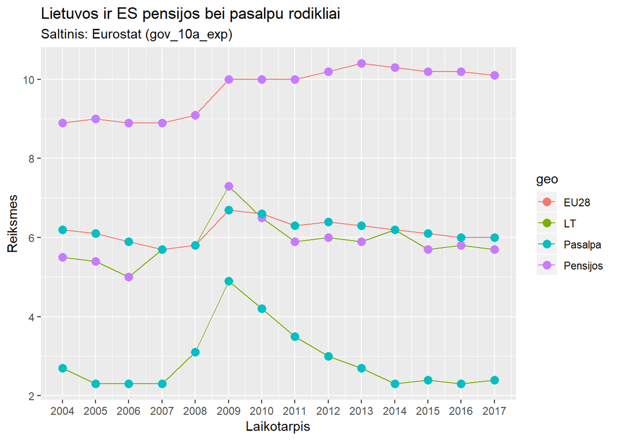

```r
ggplot(duomenys)+
        geom_line(data=duomenys, aes(x=time, y=GF1002, col=geo))+
        geom_point(aes(x=time, y=GF1002, col="Pensijos"), size = 3)+
        geom_line(data=duomenys, aes(x=time, y=pasalpa, col=geo))+
        geom_point(aes(x=time, y=pasalpa, col="Pasalpa"), size = 3)+
        scale_x_date(date_labels = "%Y", date_breaks = "1 year")+
        labs(title = "Lietuvos ir ES pensijos bei pasalpu rodikliai",
             subtitle = "Saltinis: Eurostat (gov_10a_exp)",
             x="Laikotarpis",
             y="Reiksmes")
```

## 3.4 Apskaičiuokite

Taip pat, Jūs nusprendėte pateikti lentelę, kurioje būtų matyti kiek % BVP pensijoms ir pašalpoms skyrė EU28 ir Lietuva 2017m. Visgi vien tik procentinės išraiškos nėra labai informatyvios, tad Jūs nusprendžiate pateikite lentelę (dataframe pageidautiną perleistą į lentelių formavimo komandą) susidedančią iš 2 eilučių (cofog99) ir 4 stulpelių:

- ES28 išlaidos % BVP
- LT išlaidos % BVP
- skirtumas procentiniais punktais (primenu, 1.9%-1.5%=0.4 proc.punkto)
- trečio stulpelio reikšmes sudauginkite su Lietuvos 2017m BVP (= 41857 mln eur), nes norite žinoti, kiek mln eurų reiktų skirti šioms sritims, tam kad pasiektume ES vidurkį
- PERSPĖJIMAS: kai skaičiuosite reikalingas lėšas, pasitikrinkite, ar teisingai skaičiuojate kai sudauginate su proc. punktais! :)

```r
lentele <- duomenys %>%
        filter(time == "2017-01-01")%>%
        select(1, 3, 4)
#Isivaizduoju kad bendros islaidos yra sudeta pasalpa + pensijos (gf1002)
lentele$Islaidos_proc_BVP <- lentele$GF1002+lentele$pasalpa
lentele$skirtumas <- lentele$GF1002 - lentele$pasalpa
lentele$Lesos_mln <- lentele$skirtumas*41857
names(lentele) <- c("Šalis", "Išlaidos_pensijoms", "Pašalpoms", "Procentinis_skirtumas", "Išlaidos.proc.BVP", "Lėšos.proc.BVP" )


library(knitr)
kable(lentele, caption = "Islaidu paskirtymas")
```

Islaidu paskirtymas

| Šalis | Išlaidos_pensijoms | Pašalpoms | Procentinis_skirtumas | Išlaidos.proc.BVP | Lešos.proc.BVP |
| --- | --- | --- | --- | --- | --- |
| EU28 | 10.1 | 6.0 | 16.1 | 4.1 | 171613.7 |
| LT | 5.7 | 2.4 | 8.1 | 3.3 | 138128.1 |